# Linear Regression

### Residual analysis

Some of the assumptions in the above hypothesis tests are:  
1. The mean of errors should be zero  
2. The variance of the errors should be constant across $y$  
3. The errors should be random. They should follow a random distribution

I can validate these three assumptions using the residual plots

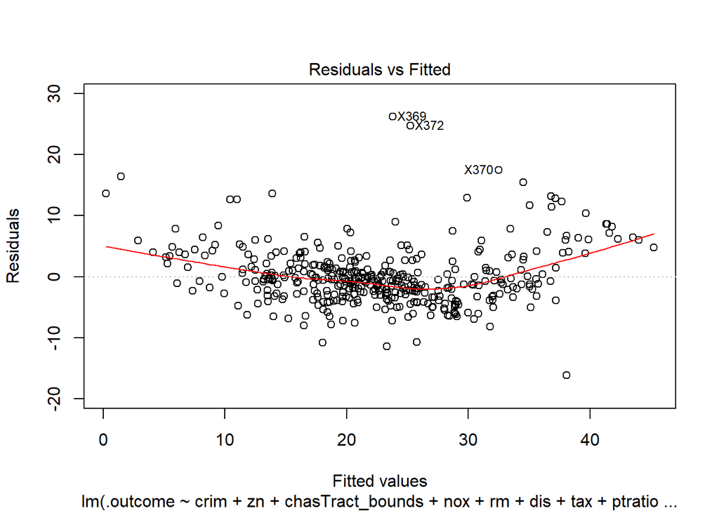

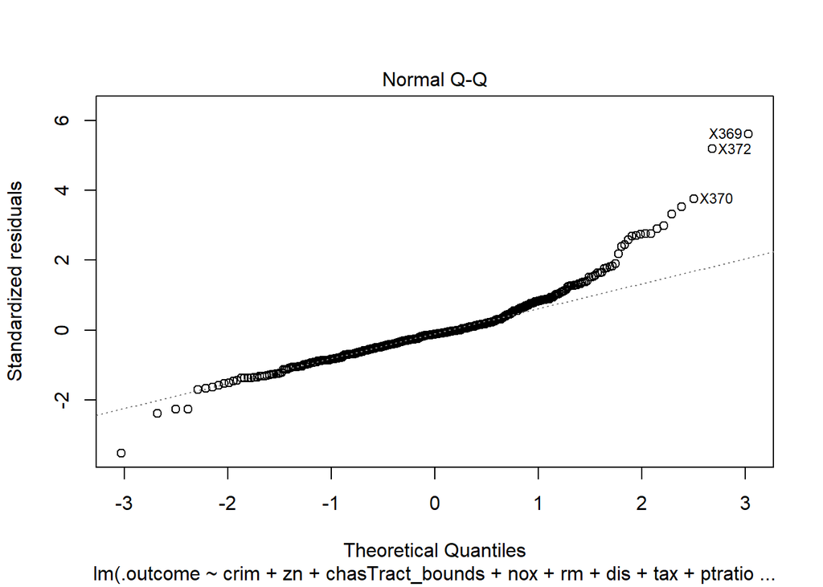

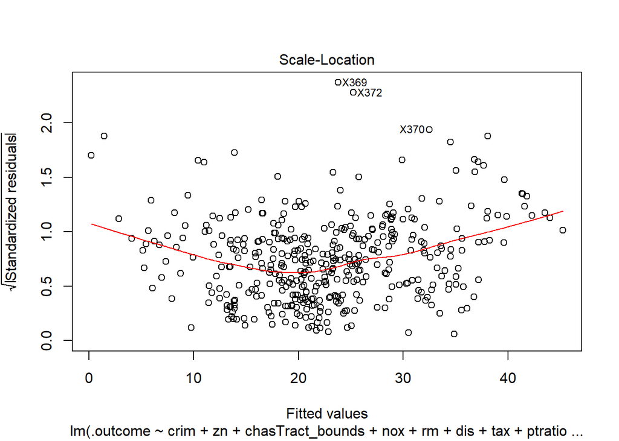

```
##
## Call:
## lm(formula = .outcome ~ crim + zn + chasTract_bounds + nox +
##     rm + dis + tax + ptratio + black + lstat + rad_catloc24,
##     data = dat)
##
## Coefficients:
##      (Intercept)              crim                zn  chasTract_bounds
##         35.63847          -0.12514           0.04218           2.03047
##              nox                rm               dis               tax
##        -17.25517           4.12029          -1.47673          -0.01007
##          ptratio             black             lstat      rad_catloc24
##         -0.96129           0.00880          -0.52637           5.66908
##
##
## ASSESSMENT OF THE LINEAR MODEL ASSUMPTIONS
## USING THE GLOBAL TEST ON 4 DEGREES-OF-FREEDOM:
## Level of Significance =  0.05
##
## Call:
##  gvlma(x = model$finalModel)
##
##                     Value   p-value                   Decision
## Global Stat        650.35 0.000e+00 Assumptions NOT satisfied!
## Skewness           125.66 0.000e+00 Assumptions NOT satisfied!
## Kurtosis           385.33 0.000e+00 Assumptions NOT satisfied!
## Link Function      120.98 0.000e+00 Assumptions NOT satisfied!
## Heteroscedasticity  18.39 1.803e-05 Assumptions NOT satisfied!
```

Observations:  
None of the three conditions are properly satisfied. Certain outlier points seem to have a huge effect on the residuals and the model. As normality conditions are not met, I cannot trust the p values from above t and F statistics.

### Multi-collinearity

From the correlation matrix, I am expecting large multicollinearity between the features.

Variation inflation factor is the value by which the square of the estimate is inflated in presence of multi-collinearity. The t-statistic is thus deflated by $\sqrt(VIF)$ and standard error of estimate is inflated by $\sqrt(VIF)$.
$$VIF = \frac{1}{1-(R_j)^2}$$
Where $R_j$ is the regression correlation coefficient between $j$th variable and all other dependent variables.
A VIF of greater than 10 is considered bad. (decreases the t-value ~3.16 times, thus increasing p-value)

```
##             crim               zn chasTract_bounds              nox
##         1.733555         2.394835         1.050701         3.810818
##               rm              dis              tax          ptratio
##         1.825246         3.581245         7.671215         1.855131
##            black            lstat     rad_catloc24
##         1.320648         2.551655         7.602218
```

The t-value for *tax* and *rad_cat* variables are inflated by $\sqrt(VIF) = \sqrt(7.6) =2.7$. The corrected t-value would be
$$t_{actual} = \frac{\beta_i}{S_e(\beta_i)} * \sqrt(VIF) = t_{pred}*\sqrt(VIF$$
Where t-predicted is the value of t in the summary table. Increasing t-value by ~2.7% decreases p further, and as both the values *tax* and *rad_cat* have p-values below 5%, increasing the t-value further will only decrease the p-value further making the two variables more significant.

### Testing over-fitting

To prevent over fitting, it is important to find the ideal number of independent variables. Mallows’s $C_p$ is used to identify the ideal number of features in the model. The best regression model is the model with the number of parameters close to $C_p$.

$$C_p = \frac{SSE_p}{MSE_{full}} -(N-2p)$$
Where N is the number of observations and p is the number of parameters.
The Mallows cp in our case is:

```
## [1] 10.18672
```

The number of features that are significant in the current model is 11.

### Auto correlation

Durbin watson is a hypothesis test to test the existence of auto correlation. The null and alternate hypothesis are:
$$H_0 : \rho_i= 0$$
$$H_1 : \rho_i \neq 0$$
The test statistic is the durbin watson statistic $D$. D is between 0 and 4. D close to 2 implies absence of auto correlation.

```
##  lag Autocorrelation D-W Statistic p-value
##    1       0.4198705      1.144239       0
##  Alternative hypothesis: rho != 0
```

## Outlier analysis

From the residual plots, I suspect that that there might be certain outliers that are adversely effecting the model. i am using the following distance measures to check for outliers in the model.  
1. Mahalanobis distance: Distance between the observation and the centroid of the values  
2. Leverages: Capacity of an observation to be influential due to having extreme predictor values (unusual combination of predictor values).  
3. Jackknife residuals (studentized residual): Division of residuals by its standard deviation  
4. Cook’s distance’: Detects observations that have a disproportionate impact on the determination of the model parameters (large change in parameters if deleted).  
5. DFBETAS: Changes in coefficients when the observations is deleted.  
6. DFFITS: Change in the fitted value when the observation is deleted (standardized by the standard error)  
7. hat: Diagonal elements of the hat matrix  
8. cov.r: Co-variance ratios

The above metrics for sample 5 observations, and outlier plots (for significant metrics) are as follows:

Outlier metrics

| dfb.1_ | dfb.crim | dfb.zn | dfb.chT_ | dfb.nox | dfb.rm | dfb.dis | dfb.tax | dfb.ptrt | dfb.blck | dfb.lstt | dfb.r_24 | dffit | cov.r | cook.d | hat | maha |
| --- | --- | --- | --- | --- | --- | --- | --- | --- | --- | --- | --- | --- | --- | --- | --- | --- |
| 0.7796401 | -0.2317501 | 0.1678140 | -0.0579735 | -0.0936772 | -1.1097413 | -0.4805830 | -0.0144256 | -0.0745656 | 0.0747545 | -1.1868934 | 0.4152958 | 1.5508236 | 0.4063263 | 0.1848802 | 0.0656965 | 59.32389 |
| 0.0147891 | 0.3645414 | -0.0178977 | 0.0107611 | 0.0119382 | -0.0058155 | 0.0304393 | 0.0005552 | 0.0161723 | -0.1159999 | -0.0610864 | -0.0882379 | 0.4029018 | 1.2799527 | 0.0135408 | 0.2094680 | 80.63853 |
| 0.0050986 | 0.0114598 | -0.0002544 | 0.0003139 | -0.0021656 | -0.0040736 | -0.0019297 | 0.0004132 | 0.0001400 | -0.0077489 | -0.0068897 | -0.0021726 | 0.0159856 | 1.1901705 | 0.0000213 | 0.1338773 | 55.40362 |
| 0.0201748 | -0.2245737 | 0.0051880 | -0.0027568 | -0.0129879 | -0.0007893 | -0.0145494 | -0.0025818 | -0.0039595 | -0.0563659 | 0.0126108 | 0.0401276 | -0.2356062 | 1.2262623 | 0.0046343 | 0.1664139 | 65.24982 |
| 0.0980385 | -0.5245638 | 0.0341992 | -0.0047776 | -0.0327019 | -0.0832358 | -0.0461418 | -0.0290283 | -0.0292670 | -0.1138749 | 0.0386572 | 0.1235709 | -0.5425691 | 1.4946534 | 0.0245556 | 0.3231086 | 126.23671 |

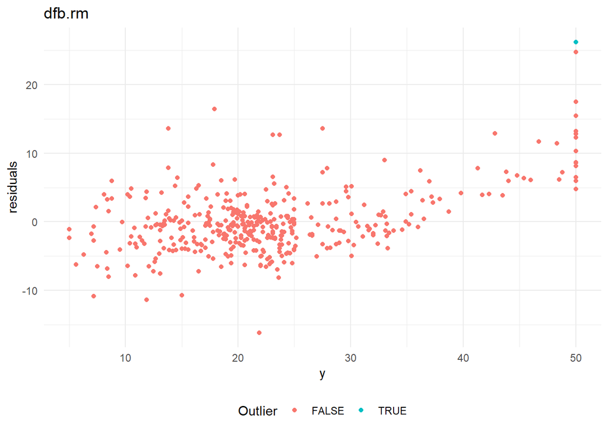

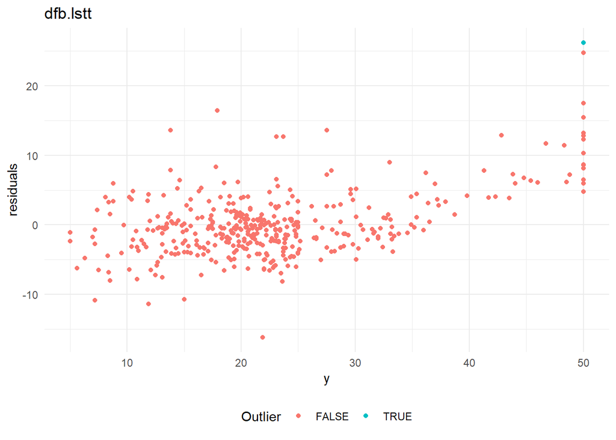

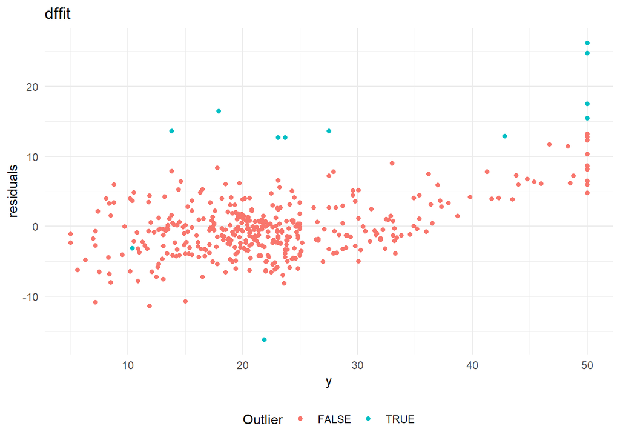

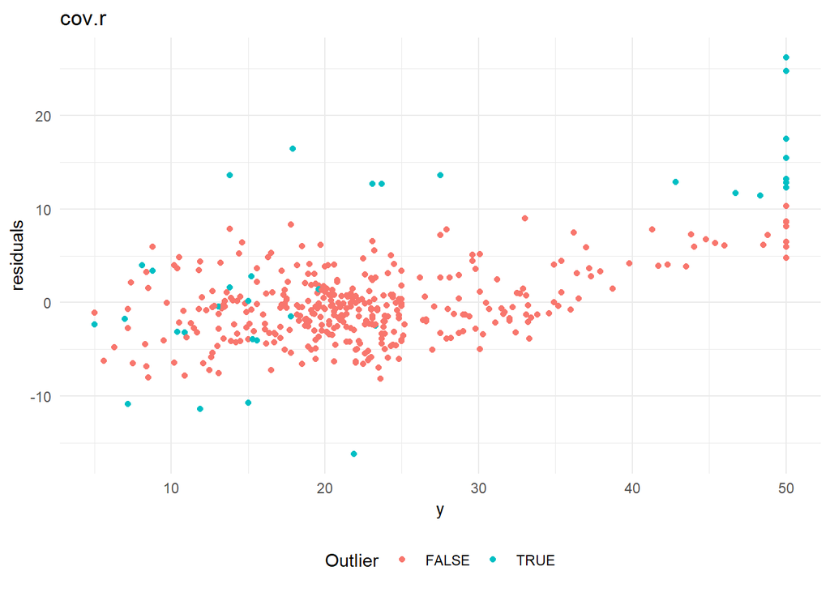

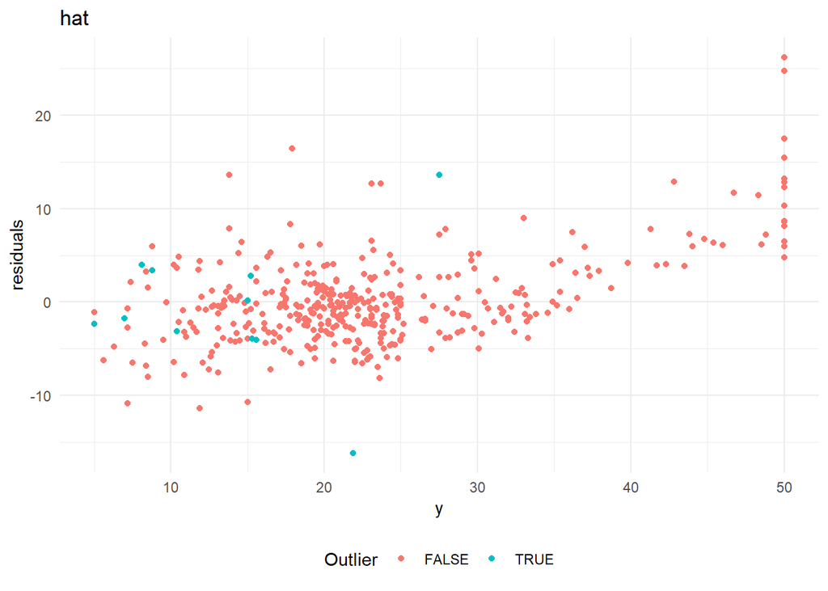

Cooks distance and leverage values plots:

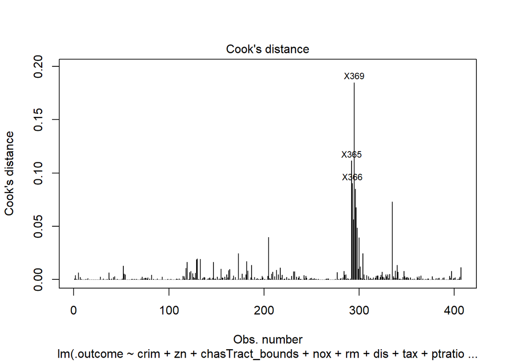

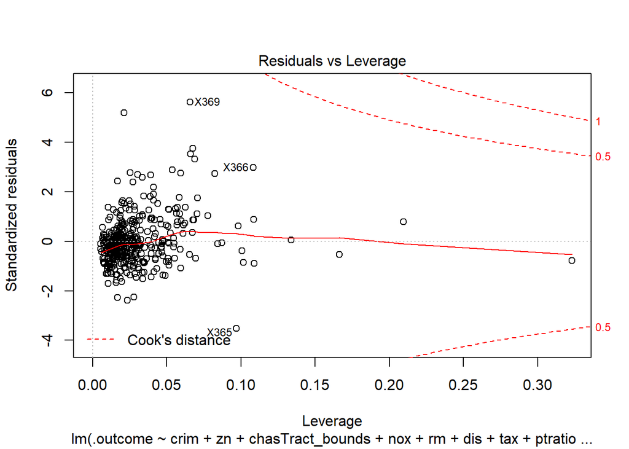

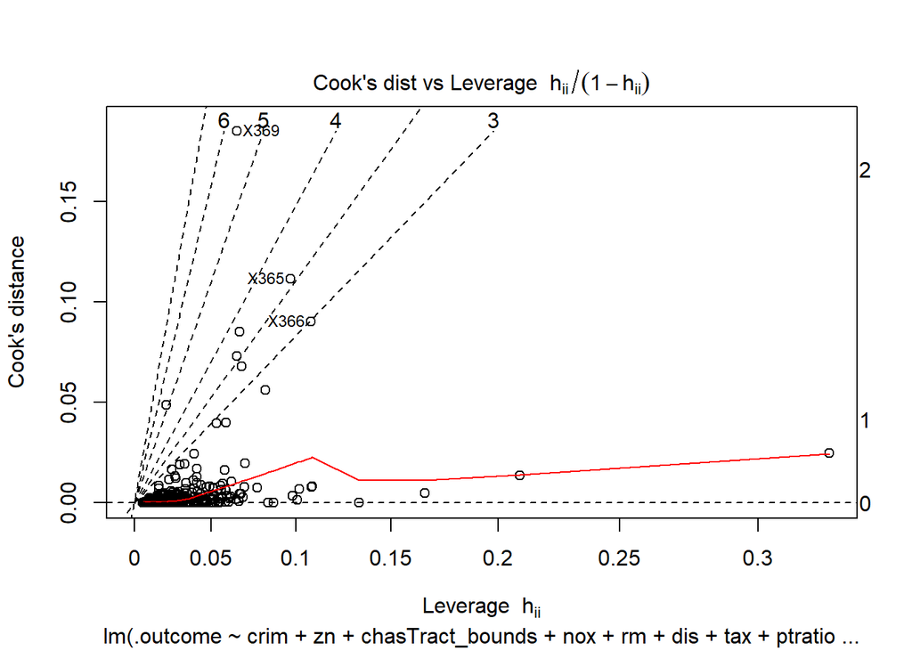

## Building a better model

Now that I know all the problems that are present in the current model, I am build a better model taking care of all of them. The current model has the following problems:  
1. Residuals are not normally distributed  
2. Residuals do not have constant variance  
3. Multicollinearity among variables  
4. Outliers affecting $\beta$ coefficients  
5. Low R-Squared

A slightly better model than the above is shown below.

```
##
## Call:
## lm(formula = .outcome ~ rm + `I(1/rm)` + `poly(dis, degree = 2)2` +
##     `I(1/dis)` + `I(1/ptratio)` + `exp(black)` + `log(lstat)` +
##     `sqrt(lstat)` + `poly(crim, degree = 2)1` + `poly(crim, degree = 2)2` +
##     `exp(indus)` + nox + `I(1/tax)` + rad_catloc24 + `rm:lstat`,
##     data = dat)
##
## Residuals:
##      Min       1Q   Median       3Q      Max
## -21.8040  -2.1502  -0.0956   1.9586  21.2613
##
## Coefficients:
##                              Estimate  Std. Error t value Pr(>|t|)
## (Intercept)                -8.295e+01   1.535e+01  -5.404 1.14e-07 ***
## rm                          1.107e+01   1.260e+00   8.786  < 2e-16 ***
## `I(1/rm)`                   1.990e+02   5.071e+01   3.925 0.000102 ***
## `poly(dis, degree = 2)2`   -9.122e+00   4.170e+00  -2.188 0.029294 *
## `I(1/dis)`                  1.965e+01   2.167e+00   9.070  < 2e-16 ***
## `I(1/ptratio)`              1.815e+02   3.119e+01   5.821 1.22e-08 ***
## `exp(black)`              -6.794e-173   0.000e+00    -Inf  < 2e-16 ***
## `log(lstat)`               -2.062e+01   2.729e+00  -7.554 3.02e-13 ***
## `sqrt(lstat)`               1.792e+01   3.439e+00   5.211 3.04e-07 ***
## `poly(crim, degree = 2)1`  -5.309e+01   6.468e+00  -8.208 3.29e-15 ***
## `poly(crim, degree = 2)2`   2.435e+01   5.810e+00   4.191 3.44e-05 ***
## `exp(indus)`               -5.070e-12   2.015e-12  -2.516 0.012264 *
## nox                        -2.090e+01   3.323e+00  -6.290 8.48e-10 ***
## `I(1/tax)`                  1.248e+03   2.990e+02   4.173 3.70e-05 ***
## rad_catloc24                5.340e+00   9.906e-01   5.391 1.22e-07 ***
## `rm:lstat`                 -2.391e-01   5.106e-02  -4.684 3.89e-06 ***
## ---
## Signif. codes:  0 '***' 0.001 '**' 0.01 '*' 0.05 '.' 0.1 ' ' 1
##
## Residual standard error: 3.664 on 391 degrees of freedom
## Multiple R-squared:  0.8561, Adjusted R-squared:  0.8506
## F-statistic:   155 on 15 and 391 DF,  p-value: < 2.2e-16
```

Modelling is an iterative process. With more effort, I could get a better model using linear regression itself. Otherwise I could use other regression techniques to get better results.

Created by Harsha Achyuthuni. For more such links, visit [www.harshaash.website](http://www.harshaash.website/log-of-posts/)